# W14：相關分析——數據間的交情

心理教育統計 2026

授課教師：陳紹慶 | e-mail: csc2009@mail.tcu.edu.tw

2026/06/01

# 本週學習目標

**概念理解**：

1. 判讀**散佈圖**（方向、強弱、線性）
2. 理解 **Pearson r** 的計算意義與範圍
3. 解讀 **$r^2$** 決定係數
4. 建立「**相關 ≠ 因果**」的批判思考

**jamovi操作**：

1. 繪製**散佈圖**
2. 製作**相關係數矩陣** (Correlation Matrix)
3. 相關係數的信賴區間與顯著性標記
4. 撰寫 APA 格式的相關分析報告

## 對應教材

- 《用 jamovi 上手統計學》[第 12 章：相關與線性迴歸](https://scgeeker.github.io/lsj-book-zh_tw/12-Correlation-and-linear-regression.html)

**簡報示範資料**：

- **parenthood**：爸爸睡眠時數、寶寶睡眠時數與爸爸暴躁程度（N = 100）
- **Anscombe’s Quartet**：四組看似相同卻截然不同的資料

**操作示範資料**： “Study2_copy.xls”, [前置處理操作錄影](https://www.youtube.com/live/_UPqXWh1-Bs?si=12PvmLH83MUL_8Q2&t=5119)

**作業資料**：個人化 `W14_Correlation_[學號].csv`

# Part 1：先看圖再談正事🧠

## 散佈圖是資料「佈局」的視覺化

散佈圖是觀察兩個連續變項關係的第一步：

- **緊密直線** → 強相關
- **鬆散雲霧** → 弱相關或無相關
- **往右上** → 正相關
- **往右下** → 負相關
- **圓形散佈** → 零相關

> 養成習慣：**先看散佈圖，再判讀相關係數！**

## 爸爸的睡眠時數 vs 爸爸暴躁程度

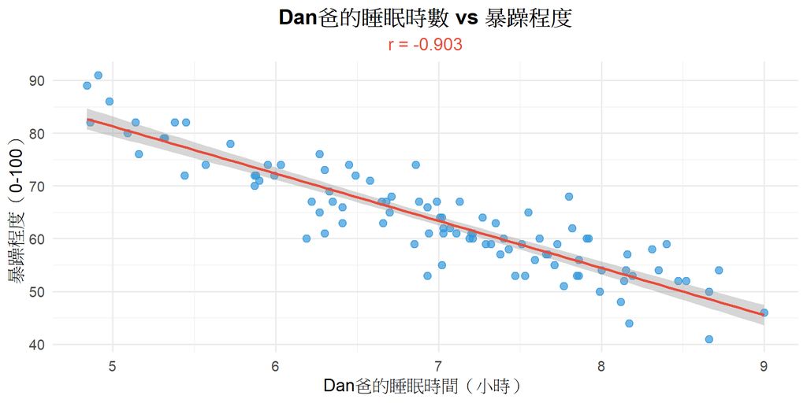

> 睡越少，脾氣越差 → **負相關**

## 三種相關方向

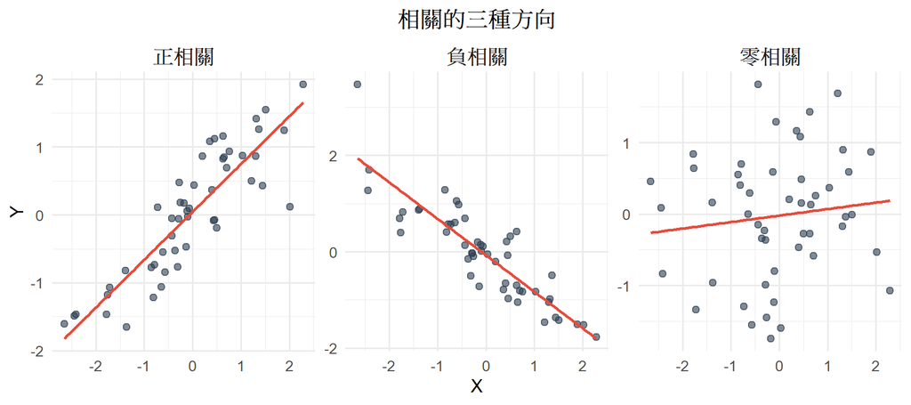

# Part 2：[安斯庫姆四重奏](https://zh.wikipedia.org/zh-tw/%E5%AE%89%E6%96%AF%E5%BA%93%E5%A7%86%E5%9B%9B%E9%87%8D%E5%A5%8F) 🧠

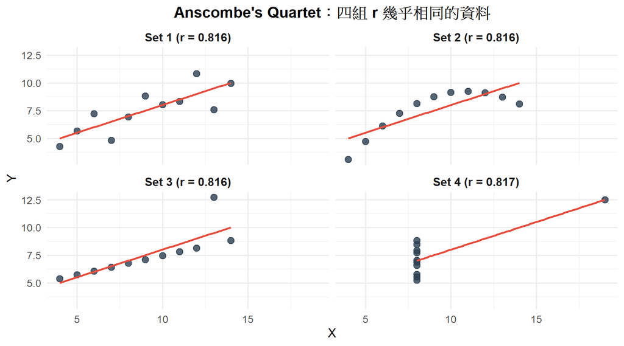

## 四重奏的教訓

四組資料的統計摘要**幾乎完全相同**：

- 相同的 $\bar{X}$、$\bar{Y}$
- 相同的 $s_X$、$s_Y$
- 相同的 $r$
- 相同的迴歸線

**但圖形完全不同**：

- Set 1：正常線性
- Set 2：曲線關係
- Set 3：一個極端離群值
- Set 4：X 幾乎不變，一個離群值撐起整條線

> **處理統計問題，先做視覺化！** 只看數字會被誤導，畫出來才能確定。

# Part 3：Pearson 相關係數 🧠👨‍💻

## Pearson r 的公式

$$r = \frac{\sum_{i=1}^{N} (X_i -
\bar{X})(Y_i - \bar{Y})}{\sqrt{\sum_{i=1}^{N}(X_i - \bar{X})^2} \cdot
\sqrt{\sum_{i=1}^{N}(Y_i - \bar{Y})^2}}$$

- 分子：X 和 Y **偏離各自平均值**的程度（共變）
- 分母：各自偏離的程度（標準化）
- 係數值域：$-1 \leq r \leq +1$ >- **散佈圖**是將$Y_i$和$X_i$排列的視覺化成品

## r 的範圍與解讀

| r 的絕對值 | 強度 | 白話 |
| --- | --- | --- |
| 0.00 - 0.10 | 幾乎無關 | 兩者沒什麼關係 |
| 0.10 - 0.30 | 弱相關 | 有點關係，但不明顯 |
| 0.30 - 0.50 | 中等相關 | 看得出趨勢 |
| 0.50 - 0.70 | 強相關 | 關係明顯 |
| 0.70 - 1.00 | 強相關 | 幾乎可以預測 |

- 經驗法則，不同領域的「強弱」標準可能不同
- r 和 Cohen’s d一樣，也是一種效果量

## parenthood 的相關矩陣

|  | dan.sleep | baby.sleep | dan.grump |
| --- | --- | --- | --- |
| **dan.sleep** | 1.000 | 0.628 | -0.903 |
| **baby.sleep** | 0.628 | 1.000 | -0.566 |
| **dan.grump** | -0.903 | -0.566 | 1.000 |

## Correlation Matrix模組操作步驟

**步驟**：

1. **Regression → Correlation Matrix**
2. 將所有連續變項拖入分析框
3. 勾選 **Pearson**（預設已勾）
4. 勾選 **Report significance**
5. 勾選 **Flag significant correlations**
6. 選用 **Confidence Intervals**（95% CI）

**結果解讀**：

- `***` 表示 $p < .001$
- `**` 表示 $p < .01$
- `*` 表示 $p < .05$

## jamovi操作：Zhang et al. (2024) Study 2

分析Study 2 的三個連續測量變項：

- **`Pre_sum`**：前測分數（先備知識）
- **`Post_sum`**：後測分數（學習成效）
- **`self_understand`**：自評理解程度（主觀感受）

Q. 先備知識是否預測學習成效？主觀感受是否與測驗結果一致？

# Part 4：$r^2$ 決定係數 🧠👨‍💻

## $r^2$ 是什麼？

$$r^2 = r \times r$$

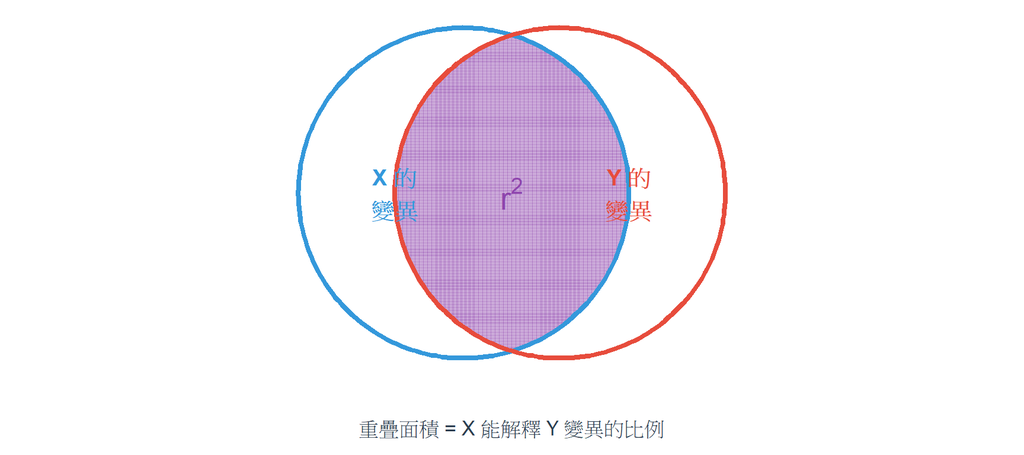

## parenthood 的 $r^2$

Dan 的睡眠 vs 暴躁程度：

$$r = -0.903 \quad \Rightarrow \quad r^2 =
0.816$$

**白話解讀**：

> 「Dan 的睡眠時間能解釋他暴躁程度的 **81.6%** 變異。」

也就是說，還有 18.4% 的暴躁程度來自其他因素（工作壓力、天氣、早餐…）

## $r^2$ 的解讀指引

| r | $r^2$ | 解釋比例 |
| --- | --- | --- |
| 0.10 | 0.01 | 1% — 幾乎沒解釋力 |
| 0.30 | 0.09 | 9% — 解釋力有限 |
| 0.50 | 0.25 | 25% — 四分之一 |
| 0.70 | 0.49 | 49% — 近半 |
| 0.90 | 0.81 | 81% — 大部分 |

> $r^2$ 比 $r$ 更能反映實際的「解釋力」

## jamovi操作：Zhang et al. (2024) Study 2

從相關矩陣結果中，選出顯著相關的變項對，使用`Linear Regression`計算 $r^2$：

- **`Pre_sum` × `Post_sum`**：先備知識能解釋多少比例的後測成績變異？
- **`self_understand` × `Post_sum`**：主觀理解感受能解釋多少比例的測驗結果變異？

# Part 5：相關 ≠ 因果🧠

## 偽相關案例1~冰淇淋與溺水

**事實**：冰淇淋銷量與溺水人數呈正相關

**錯誤推論**：吃冰淇淋會導致溺水？

**真正原因**：

```
          氣溫（第三變項）
         ╱              ╲
        ↓                ↓
  冰淇淋銷量 ←--?--→ 溺水人數
```

**氣溫**同時影響了兩個變項，造成「虛假相關」（Spurious Correlation）

## 偽相關案例2～移情別戀迷因

有人發現：**移情別戀迷因（[Distracted Boyfriend](https://en.wikipedia.org/wiki/Distracted_boyfriend)）搜尋量**與**紐澤西州統計專家人數**高度相關（$r = 0.96$）

**Takeaway**

- 有足夠多的變項，總能找到「相關」
- AI時代更容易出現偽相關
- 網站推薦：[Spurious Correlations](https://www.tylervigen.com/spurious-correlations)

## 三種可能的解釋

A 和 B 會有顯著相關，至少有三種可能：

| 解釋 | 方向 | 例子 |
| --- | --- | --- |
| A 導致 B | A → B | 睡眠不足 → 脾氣差 |
| B 導致 A | B → A | 脾氣差 → 睡不好 |
| C 同時影響 A 和 B | C → (A, B) | 寶寶哭鬧 → Dan爸睡不好變暴躁 |

**只有實驗設計**（隨機分派 + 操弄自變項）才能建立因果關係。

- 相關分析只能告訴你「有關係」，不能告訴你「誰是原因，誰是結果」。

# Part 6：本週作業

## 本週作業：相關分析實作

**資料**：個人化 `W14_Correlation_[學號].csv`

你的資料包含：

| 變項 | 類型 | 說明 |
| --- | --- | --- |
| `Study_Hours` | Continuous | 每週讀書時數 |
| `Total_Score` | Continuous | 期末總成績 |
| `RT_ms` | Continuous | 作業反應時間（毫秒） |

## 任務 1：散佈圖

**操作**：

1. 為三對變項各繪製一張散佈圖：
   - Study_Hours vs Total_Score
   - Study_Hours vs RT_ms
   - RT_ms vs Total_Score
2. 在報告中描述每張圖的方向與強弱

## 任務 2：相關矩陣

**操作**：

1. 執行 **Regression → Correlation Matrix**
2. 勾選 Pearson、Significance
3. 在報告中列出所有 r 值
4. 執行 **Regression → Linear Regression**
5. 計算 $r^2$ 並做白話解讀

## 任務 3：因果議題討論

**反思問題**：

1. **Q1**：Study_Hours 與 Total_Score 的相關係數是多少？$r^2$ 是多少？請用一句白話解釋 $r^2$ 的意義。
2. **Q2**：「讀書時間多 → 成績好」是唯一可能的解釋嗎？請說明至少兩種替代解釋。
3. **Q3**：如果要證明「讀書時間確實會提升成績」，應該採用什麼研究設計？為什麼相關分析不夠？

## 繳交要求

**檔案 1：學號_姓名_W14_Lab.omv**

- 含散佈圖（3 張）
- 含相關矩陣（Pearson, p values）

**檔案 2：學號_姓名_W14_Report.docx**

- 散佈圖描述
- 相關矩陣結果與 $r^2$ 解讀
- 3 題反思問題回答

**繳交期限**：本日下課後，當天午夜12:00之前

# 小結與展望

## 本週核心概念

1. **先做視覺化**：散佈圖永遠是第一步（Anscombe 的教訓）
2. **Pearson r**：衡量線性關係的方向與強度（-1 到 +1）
3. **$r^2$**：解釋變異量的百分比（比 r 更直觀）
4. **相關 ≠ 因果**：A→B、B→A、C→(A,B) 三種可能
5. **jamovi 操作**：Correlation Matrix + 散佈圖

## 下週預告

**下週問題**：

- 如果想用 X **預測** Y 呢？
- 迴歸線的斜率和截距代表什麼？
- 什麼是線性迴歸？

## 課後資源

**電子書**：[第 12 章：相關與線性迴歸](https://scgeeker.github.io/lsj-book-zh_tw/12-Correlation-and-linear-regression.html)

**關鍵術語對照**：

| 中文 | 英文 | 符號 |
| --- | --- | --- |
| 散佈圖 | Scatterplot | - |
| 皮爾森相關係數 | Pearson correlation coefficient | $r$ |
| 決定係數 | Coefficient of determination | $r^2$ |
| 相關矩陣 | Correlation matrix | - |
| 虛假相關 | Spurious correlation | - |
| 第三變項 | Third variable (confound) | - |